# Assessment 1 MATH70094 Programming for Data Science Autumn 2025

## Kutadgu Gokalp Demirci - 06071571

# Question 2 (20 marks)

You have heard that an experienced spy should not only be proficient in Python, but also in R. Your task in this question is to provide R statements and functions to encode and decode string messages, as well as to do a simple analysis of a message. Some helpful functions/techniques for this question are:

- cat, length, nchar, paste, strsplit, toupper, intToUtf8
- sapply, grep, gsup
- which, factor

It is easy to see how to use these functions with the R help by typing `?length` in the R console. There are usually several ways to answer each question, and sometimes you might not use all or even any of the suggested functions.

```r
# Do not alter this

msg1 <- "THE PASSWORD IS MY NAME"
msg2 <- "I AM A SPY WRITING A SPY MESSAGE"
msg3 <- "XLMW*MW*XLI*HIVW*WLSYWI*UVG*MW*XLI*WWT*UIAG*OLKDL*XLI*XLMW*AU*AU*XLMW*MW*XLI*HIVW*WLSYWI*UVG*MW*XLI*WWT*UIAG*OLKDL*XLI*XLMW*AU*AU"

# Do not alter this
```

## Code clarity (1 mark)

There is a famous saying among software developers that code is read more often than it is written. Marks will be awarded (or not awarded) based on the clarity of the code and appropriate use of comments.

## Part A (2 marks)

Repeat the task in Question 1, Part A, but now using R.

```r
allowed_caracters <-unlist(strsplit("QWERTYUIOPASDFGHJKLZXCVBNM ", split = ""))
# print(allowed_caracters)
msg_caracters <-unlist(strsplit(msg1, split = ""))
# print(msg_caracters)

is_valid <- all(msg_caracters %in% allowed_caracters)
cat("The message contains only capital letters and whitespace:", is_valid, "\n")
```

```
## The message contains only capital letters and whitespace: TRUE
```

## Part B (8 marks)

Repeat the task in Question 1, Part B, but now using R.

```r
encoding_message <- function(message) {

  # Step 1
  step1 <- function(letter) {
    if (letter == " ") return(" ")
    new_letter <- intToUtf8((utf8ToInt(letter) - utf8ToInt("A") + 3) %% 26 + utf8ToInt("A"))
    return(new_letter)
  }

  # Apply step1 to each character
  shifted <- sapply(message, step1)

  #Step 2
  reversed <- rev(shifted)

  #Step 3
  replaced <- gsub(" ", "*", reversed)

  #Step 4
  for (i in 1:length(replaced)) {
    if (i %% 2 == 1) {     #This is left as one instead of 0 to match the zero-index of python
      replaced[i] = tolower(replaced[i])
      }
    }
  # Combine back into string

  encoded <- paste0('"\\#\\#\\#', paste0(replaced, collapse = ""), '\\#\\#\\#"')
  return(encoded)
}

cat(encoding_message(msg_caracters), "\n")
```

```
## "\#\#\#hPdQ*Bp*vL*GuRzVvDs*hKw\#\#\#"
```

## Part C (2 marks)

You have intercepted a message string stored in `msg2`. In order to identify if this message is important your task is to write R statements to locate the first occurrence (index) of the keyword `"SPY"` in the message. Print this index preceded by an informative print statement.

For example, if the message string is `"I AM A SPY"`, then you should return

`The word index of the first occurrence of the keyword SPY is: 4.`

```r
split_message <- unlist(strsplit(msg2, " "))
#print(split_message)
first_occurrence_index <- min(which(split_message=="SPY"))
cat("The word index of the first occurrence of the keyword SPY is: ", first_occurrence_index, ".", sep = "")
```

```
## The word index of the first occurrence of the keyword SPY is: 4.
```

## Part D (4 marks)

You have intercepted another encoded message string stored in `msg3`. Your task is to write R statements to analyse the message as follows:

### Part D(i) (2 marks)

Count how often each letter $A,B,..,Z$ appears in the message. Plot a bar chart of the letter frequencies.

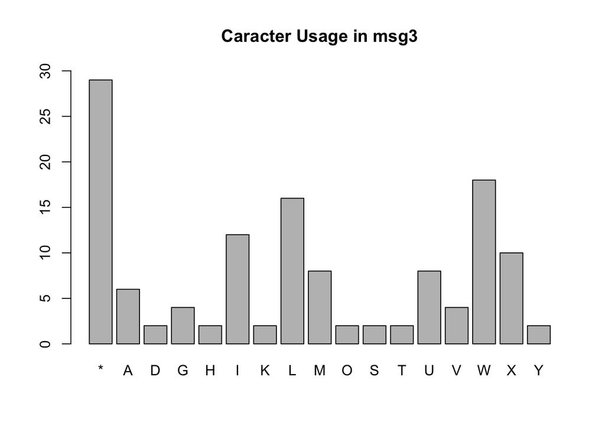

```r
caracters_in_message <- unlist(strsplit(msg3, split = ""))
caracter_usage <- table(factor(caracters_in_message))

barplot(caracter_usage,
        main = "Caracter Usage in msg3",
        ylim = c(0, 30))
```

### Part D(ii) (2 marks)

Compute the length of each word in the message. Plot a histogram of the word lengths.

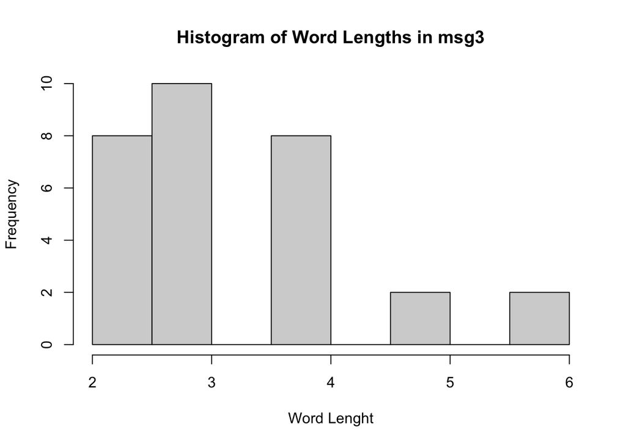

```r
separeted_words <- unlist(strsplit(msg3, split = "\\*"))
word_lenghts <- nchar(separeted_words)
hist(word_lenghts,
     main = "Histogram of Word Lengths in msg3",
     xlab = "Word Lenght")
```

## Part E (3 marks)

Write an R function to generate a spy name from a person’s first and last names. The function should take as input a string with the person’s first name and a string with the person’s last name, and return a string with the spy name. The spy name is generated as follows:

- Convert the first and last names to uppercase.
- Keep the first two letters of the first name, followed by the last two letters of the last name and conclude by a random two-digit number.

Print your spy name preceded by an informative print statement.

```r
first_name <- "Kutadgu"
last_name <- "Demirci"

spy_name_generator <- function(first_name_v, last_name_v) {

  first_name_v <- toupper(first_name_v)
  last_name_v <- toupper(last_name_v)


  fn_part <- substr(first_name_v, 1, 2)


  ln_length <- nchar(last_name_v)
  ln_part <- substr(last_name_v, ln_length-1, ln_length)


  random_digits <- paste0(sample(0:9, 2, replace = TRUE), collapse = "")

  # Combine all parts
  spy_name <- paste0(fn_part, ln_part, random_digits)

  return(spy_name)
}

# Generate a spy name
spy_name_generator(first_name, last_name)
```

```
## [1] "KUCI47"
```